# Mini-Project #02 — Making Backyards Affordable for All

Author

Eveline Lindqvist Nilsson

Published

October 31, 2025

## Project Description

This mini project for STA 9750 examines housing affordability which is a major challenge in cities in the United States especially New York City. The goal is to identify cities most supportive of new housing development or YIMBY by analyzing census and real estate data.

The results will be used to create a short policy brief to guide politicians in supporting a federal YIMBY incentive program and highlight districts that could benefit from these policies.

This project helps students strengthen skills in data analysis critical thinking and communication by using advanced data manipulation, creating clear visualizations, and presenting complex information in an understandable way.

# Executive Summary

I analyzed housing and census data to identify cities most supportive of new housing. The key takeaway is that some cities clearly show strong support for housing development, which can guide policy decisions.

# Data & Reproducibility Notes

# Task 1: Data Import

```r
if(!dir.exists(file.path("data", "mp02"))){
    dir.create(file.path("data", "mp02"), showWarnings=FALSE, recursive=TRUE)
}

ensure_package <- function(pkg){
    pkg <- as.character(substitute(pkg))
    options(repos = c(CRAN = "https://cloud.r-project.org"))
    if(!require(pkg, character.only=TRUE, quietly=TRUE)) install.packages(pkg)
    stopifnot(require(pkg, character.only=TRUE, quietly=TRUE))
}

ensure_package(tidyverse)
ensure_package(glue)
ensure_package(readxl)
ensure_package(tidycensus)

get_acs_all_years <- function(variable, geography="cbsa",
                              start_year=2009, end_year=2023){
    fname <- glue("{variable}_{geography}_{start_year}_{end_year}.csv")
    fname <- file.path("data", "mp02", fname)

    if(!file.exists(fname)){
        YEARS <- seq(start_year, end_year)
        YEARS <- YEARS[YEARS != 2020] # Drop 2020 - No survey (covid)

        ALL_DATA <- map(YEARS, function(yy){
            tidycensus::get_acs(geography, variable, year=yy, survey="acs1") |>
                mutate(year=yy) |>
                select(-moe, -variable) |>
                rename(!!variable := estimate)
        }) |> bind_rows()

        write_csv(ALL_DATA, fname)
    }

    read_csv(fname, show_col_types=FALSE)
}

# Household income (12 month)
INCOME <- get_acs_all_years("B19013_001") |>
    rename(household_income = B19013_001)

# Monthly rent
RENT <- get_acs_all_years("B25064_001") |>
    rename(monthly_rent = B25064_001)

# Total population
POPULATION <- get_acs_all_years("B01003_001") |>
    rename(population = B01003_001)

# Total number of households
HOUSEHOLDS <- get_acs_all_years("B11001_001") |>
    rename(households = B11001_001)
```

```r
get_building_permits <- function(start_year = 2009, end_year = 2023){
    fname <- glue("housing_units_{start_year}_{end_year}.csv")
    fname <- file.path("data", "mp02", fname)

    if(!file.exists(fname)){
        HISTORICAL_YEARS <- seq(start_year, 2018)

        HISTORICAL_DATA <- map(HISTORICAL_YEARS, function(yy){
            historical_url <- glue("https://www.census.gov/construction/bps/txt/tb3u{yy}.txt")

            LINES <- readLines(historical_url)[-c(1:11)]

            CBSA_LINES <- str_detect(LINES, "^[[:digit:]]")
            CBSA <- as.integer(str_sub(LINES[CBSA_LINES], 5, 10))

            PERMIT_LINES <- str_detect(str_sub(LINES, 48, 53), "[[:digit:]]")
            PERMITS <- as.integer(str_sub(LINES[PERMIT_LINES], 48, 53))

            data_frame(CBSA = CBSA,
                       new_housing_units_permitted = PERMITS,
                       year = yy)
        }) |> bind_rows()

        CURRENT_YEARS <- seq(2019, end_year)

        CURRENT_DATA <- map(CURRENT_YEARS, function(yy){
            current_url <- glue("https://www.census.gov/construction/bps/xls/msaannual_{yy}99.xls")

            temp <- tempfile()

            download.file(current_url, destfile = temp, mode="wb")

            fallback <- function(.f1, .f2){
                function(...){
                    tryCatch(.f1(...),
                             error=function(e) .f2(...))
                }
            }

            reader <- fallback(read_xlsx, read_xls)

            reader(temp, skip=5) |>
                na.omit() |>
                select(CBSA, Total) |>
                mutate(year = yy) |>
                rename(new_housing_units_permitted = Total)
        }) |> bind_rows()

        ALL_DATA <- rbind(HISTORICAL_DATA, CURRENT_DATA)

        write_csv(ALL_DATA, fname)

    }

    read_csv(fname, show_col_types=FALSE)
}

PERMITS <- get_building_permits()
```

```r
ensure_package(httr2)
ensure_package(rvest)
get_bls_industry_codes <- function(){
    fname <- fname <- file.path("data", "mp02", "bls_industry_codes.csv")

    if(!file.exists(fname)){

        resp <- request("https://www.bls.gov") |>
            req_url_path("cew", "classifications", "industry", "industry-titles.htm") |>
            req_headers(`User-Agent` = "Mozilla/5.0 (Macintosh; Intel Mac OS X 10.15; rv:143.0) Gecko/20100101 Firefox/143.0") |>
            req_error(is_error = \(resp) FALSE) |>
            req_perform()

        resp_check_status(resp)

        naics_table <- resp_body_html(resp) |>
            html_element("#naics_titles") |>
            html_table() |>
            mutate(title = str_trim(str_remove(str_remove(`Industry Title`, Code), "NAICS"))) |>
            select(-`Industry Title`) |>
            mutate(depth = if_else(nchar(Code) <= 5, nchar(Code) - 1, NA)) |>
            filter(!is.na(depth))

        naics_table <- naics_table |>
            filter(depth == 4) |>
            rename(level4_title=title) |>
            mutate(level1_code = str_sub(Code, end=2),
                   level2_code = str_sub(Code, end=3),
                   level3_code = str_sub(Code, end=4)) |>
            left_join(naics_table, join_by(level1_code == Code)) |>
            rename(level1_title=title) |>
            left_join(naics_table, join_by(level2_code == Code)) |>
            rename(level2_title=title) |>
            left_join(naics_table, join_by(level3_code == Code)) |>
            rename(level3_title=title) |>
            select(-starts_with("depth")) |>
            rename(level4_code = Code) |>
            select(level1_title, level2_title, level3_title, level4_title,
                   level1_code,  level2_code,  level3_code,  level4_code)

        write_csv(naics_table, fname)
    }

    read_csv(fname, show_col_types=FALSE)

}

INDUSTRY_CODES <- get_bls_industry_codes()
```

```r
ensure_package(httr2)
ensure_package(rvest)
get_bls_qcew_annual_averages <- function(start_year=2009, end_year=2023){
    fname <- glue("bls_qcew_{start_year}_{end_year}.csv.gz")
    fname <- file.path("data", "mp02", fname)

    YEARS <- seq(start_year, end_year)
    YEARS <- YEARS[YEARS != 2020] # Drop Covid year to match ACS

    if(!file.exists(fname)){
        ALL_DATA <- map(YEARS, .progress=TRUE, possibly(function(yy){
            fname_inner <- file.path("data", "mp02", glue("{yy}_qcew_annual_singlefile.zip"))

            if(!file.exists(fname_inner)){
                request("https://www.bls.gov") |>
                    req_url_path("cew", "data", "files", yy, "csv",
                                 glue("{yy}_annual_singlefile.zip")) |>
                    req_headers(`User-Agent` = "Mozilla/5.0 (Macintosh; Intel Mac OS X 10.15; rv:143.0) Gecko/20100101 Firefox/143.0") |>
                    req_retry(max_tries=5) |>
                    req_perform(fname_inner)
            }

            if(file.info(fname_inner)$size < 755e5){
                warning(sQuote(fname_inner), "appears corrupted. Please delete and retry this step.")
            }

            read_csv(fname_inner,
                     show_col_types=FALSE) |>
                mutate(YEAR = yy) |>
                select(area_fips,
                       industry_code,
                       annual_avg_emplvl,
                       total_annual_wages,
                       YEAR) |>
                filter(nchar(industry_code) <= 5,
                       str_starts(area_fips, "C")) |>
                filter(str_detect(industry_code, "-", negate=TRUE)) |>
                mutate(FIPS = area_fips,
                       INDUSTRY = as.integer(industry_code),
                       EMPLOYMENT = as.integer(annual_avg_emplvl),
                       TOTAL_WAGES = total_annual_wages) |>
                select(-area_fips,
                       -industry_code,
                       -annual_avg_emplvl,
                       -total_annual_wages) |>
                # 10 is a special value: "all industries" , so omit
                filter(INDUSTRY != 10) |>
                mutate(AVG_WAGE = TOTAL_WAGES / EMPLOYMENT)
        })) |> bind_rows()

        write_csv(ALL_DATA, fname)
    }

    ALL_DATA <- read_csv(fname, show_col_types=FALSE)

    ALL_DATA_YEARS <- unique(ALL_DATA$YEAR)

    YEARS_DIFF <- setdiff(YEARS, ALL_DATA_YEARS)

    if(length(YEARS_DIFF) > 0){
        stop("Download failed for the following years: ", YEARS_DIFF,
             ". Please delete intermediate files and try again.")
    }

    ALL_DATA
}

WAGES <- get_bls_qcew_annual_averages()
```

## Extra Credit Opportunity #01: Relationship Diagram

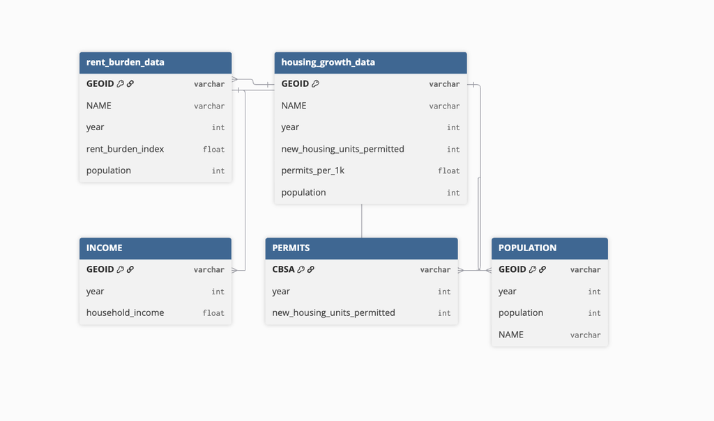

```r
knitr::include_graphics("Diagram.png")
```

# Task 2: Multi-Table Questions

## Q2.1

```r
# Top CBSA by permits in 2010–2019 (inclusive)
q2_1 <- PERMITS |>
  filter(dplyr::between(year, 2010, 2019)) |>
  group_by(CBSA) |>
  summarise(total_permits = sum(new_housing_units_permitted, na.rm = TRUE), .groups = "drop") |>
  arrange(desc(total_permits)) |>
  left_join(INCOME |> select(GEOID, NAME) |> distinct(), join_by(CBSA == GEOID))

# Creating an interactive, publication quality table
library(DT)
library(htmltools)

q2_1_tbl <- q2_1 |>
  dplyr::transmute(
    `CBSA Name` = NAME,
    `CBSA Code` = as.character(CBSA),
    `Permits (2010–2019)` = total_permits
  ) |>
  dplyr::arrange(dplyr::desc(`Permits (2010–2019)`))

datatable(
  q2_1_tbl,
  rownames = FALSE,
  class = "compact stripe hover order-column nowrap",
  caption = tags$caption(
    style = "caption-side: top; text-align: left; font-weight:600;",
    "New housing units permitted by CBSA (2010–2019)"
  ),
  options = list(
    pageLength = 10,
    autoWidth  = TRUE,
    dom        = "Bfrtip",
    buttons    = c("copy", "csv", "excel"),
    order      = list(list(2, "desc")) # sort by permits
  ),
  extensions = c("Buttons")
) |>
  formatCurrency(
    "Permits (2010–2019)",
    currency = "", digits = 0, mark = ",", before = FALSE
  )
```

| CBSA Name | CBSA Code | Permits (2010–2019) |
| --- | --- | --- |
| Houston-Sugar Land-Baytown, TX Metro Area | 26420 | 482075 |
| Houston-The Woodlands-Sugar Land, TX Metro Area | 26420 | 482075 |
| Houston-Pasadena-The Woodlands, TX Metro Area | 26420 | 482075 |
| Dallas-Fort Worth-Arlington, TX Metro Area | 19100 | 460826 |
| New York-Northern New Jersey-Long Island, NY-NJ-PA Metro Area | 35620 | 446020 |
| New York-Newark-Jersey City, NY-NJ-PA Metro Area | 35620 | 446020 |
| New York-Newark-Jersey City, NY-NJ Metro Area | 35620 | 446020 |
| Atlanta-Sandy Springs-Marietta, GA Metro Area | 12060 | 254377 |
| Atlanta-Sandy Springs-Roswell, GA Metro Area | 12060 | 254377 |
| Atlanta-Sandy Springs-Alpharetta, GA Metro Area | 12060 | 254377 |

[output cut: 545 more lines]

**Answer:**

From 2010–2019, Houston-The Woodlands-Sugar Land, TX Metropolitan Statistical Area (CBSA 26420) permitted the greatest number of new housing units, totaling approximately 482,075 units.

## 2. In what year did Albuquerque, NM (CBSA Number 10740) permit the most new housing units?

```r
q2_2 <- PERMITS |>
  filter(CBSA == 10740) |>
  arrange(desc(new_housing_units_permitted))

library(DT)
library(htmltools)

q2_2_tbl <- q2_2 |>
  dplyr::transmute(
    Year = year,
    `New Housing Units Permitted` = new_housing_units_permitted
  ) |>
  dplyr::arrange(desc(`New Housing Units Permitted`))

datatable(
  q2_2_tbl,
  rownames = FALSE,
  class = "compact stripe hover order-column nowrap",
  caption = tags$caption(
    style = "caption-side: top; text-align: left; font-weight:600;",
    "New Housing Units Permitted in Albuquerque CBSA (2010–2020)"
  ),
  options = list(
    pageLength = 10,
    autoWidth  = TRUE,
    dom        = "Bfrtip",
    buttons    = c("copy", "csv", "excel"),
    order      = list(list(1, "desc"))
  ),
  extensions = c("Buttons")
) |>
  formatCurrency(
    "New Housing Units Permitted",
    currency = "", digits = 0, mark = ",", before = FALSE
  )
```

| Year | New Housing Units Permitted |
| --- | --- |
| 2021 | 4021 |
| 2022 | 2852 |
| 2023 | 2834 |
| 2013 | 2606 |
| 2014 | 2543 |
| 2016 | 2465 |
| 2015 | 2295 |
| 2017 | 2256 |
| 2018 | 2186 |
| 2019 | 2148 |

[output cut: 5 more lines]

**Answer:** The highest number of new housing units permitted in Albuquerque CBSA was in 2021, totaling 4,021 units.

## 3. Which state (not CBSA) had the highest average individual income in 2015?

```r
INCOME |>
  filter(year == 2015) |>
  left_join(HOUSEHOLDS |> filter(year == 2015), join_by(GEOID == GEOID)) |>
  mutate(`Total Income Per CBSA` = household_income * households,
         `Name` = str_extract(NAME.x, ", (.{2})", group=1)) |>
  select(GEOID, Name, `Total Income Per CBSA`) |>
  left_join(POPULATION |> filter(year == 2015), join_by(GEOID == GEOID)) |>
  rename(Population = population) |>
  select(GEOID, Name, `Total Income Per CBSA`, Population) |>
  mutate(`Average Individual Income` = `Total Income Per CBSA` / `Population`) |>
  arrange(desc(`Average Individual Income`)) |>
  datatable(options = list(searching = FALSE, info = FALSE))
```

|  | GEOID | Name | Total Income Per CBSA | Population | Average Individual Income |
| --- | --- | --- | --- | --- | --- |
| 1 | 41940 | CA | 66424876960 | 1976836 | 33601.61235428735 |
| 2 | 47900 | DC | 202663489140 | 6098283 | 33232.87704752305 |
| 3 | 41860 | CA | 149587187826 | 4656132 | 32126.92162206742 |
| 4 | 14860 | CT | 28821488592 | 948053 | 30400.71450857705 |
| 5 | 12700 | MA | 6441706002 | 214333 | 30054.66261378322 |
| 6 | 15680 | MD | 3323826727 | 111413 | 29833.38324073492 |
| 7 | 14460 | MA | 140473214000 | 4774321 | 29422.65800728522 |
| 8 | 42660 | WA | 108267370482 | 3733580 | 28998.27256466983 |
| 9 | 31700 | NH | 11644778994 | 406678 | 28633.90445020385 |
| 10 | 33260 | TX | 4673396787 | 165427 | 28250.50800050778 |

[output cut: 506 more lines]

**Answer:**

## 4. What is the last year in which the NYC CBSA had the most data scientists in the country?

```r
acs_key <- INCOME |>
  filter(year == max(year, na.rm = TRUE)) |>
  select(GEOID, NAME) |>
  distinct() |>
  mutate(std_cbsa = paste0("C", GEOID))   # e.g., "C35620" for NYC

# 2) Leaders by year for NAICS 5182
leaders_5182 <- WAGES |>
  filter(INDUSTRY == 5182) |>
  group_by(FIPS, YEAR, INDUSTRY) |>
  summarise(EMP_DS = sum(EMPLOYMENT, na.rm = TRUE), .groups = "drop") |>
  # Pad BLS CBSA code: "C3562" -> "C35620" to match ACS
  mutate(std_cbsa = if_else(nchar(FIPS) == 5, paste0(FIPS, "0"), FIPS)) |>
  arrange(YEAR, desc(EMP_DS)) |>
  group_by(YEAR) |>
  slice_max(order_by = EMP_DS, n = 1, with_ties = FALSE) |>
  ungroup() |>
  left_join(acs_key, by = "std_cbsa") |>
  select(std_cbsa, YEAR, INDUSTRY, EMP_DS, GEOID, NAME)

# 3) Last year NYC led (NYC std_cbsa = "C35620")
nyc_last_year <- leaders_5182 |>
  filter(std_cbsa == "C35620") |>
  summarise(last_year_led = max(YEAR, na.rm = TRUE))
library(DT)
library(htmltools)

#table of yearly leaders for NAICS 5182
leaders_5182_tbl <- leaders_5182 |>
  dplyr::transmute(
    Year = YEAR,
    `CBSA Code` = std_cbsa,
    `CBSA Name` = NAME,
    `NAICS` = INDUSTRY,
    `Employment (NAICS 5182)` = EMP_DS
  ) |>
  dplyr::arrange(Year)

datatable(
  leaders_5182_tbl,
  rownames = FALSE,
  class = "compact stripe hover order-column nowrap",
  caption = tags$caption(
    style = "caption-side: top; text-align: left; font-weight:600;",
    "Yearly leader by employment in NAICS 5182 (Data Processing, Hosting & Related Services)"
  ),
  options = list(
    pageLength = 15,
    autoWidth  = TRUE,
    dom        = "Bfrtip",
    buttons    = c("copy", "csv", "excel"),
    order      = list(list(0, "asc"))
  ),
  extensions = c("Buttons")
) |>
  formatRound("Employment (NAICS 5182)", digits = 0, interval = 3, mark = ",")
```

| Year | CBSA Code | CBSA Name | NAICS | Employment (NAICS 5182) |
| --- | --- | --- | --- | --- |
| 2009 | C35620 | New York-Newark-Jersey City, NY-NJ Metro Area | 5182 | 16349 |
| 2010 | C19100 | Dallas-Fort Worth-Arlington, TX Metro Area | 5182 | 13238 |
| 2011 | C19100 | Dallas-Fort Worth-Arlington, TX Metro Area | 5182 | 13283 |
| 2012 | C35620 | New York-Newark-Jersey City, NY-NJ Metro Area | 5182 | 14423 |
| 2013 | C35620 | New York-Newark-Jersey City, NY-NJ Metro Area | 5182 | 14251 |
| 2014 | C35620 | New York-Newark-Jersey City, NY-NJ Metro Area | 5182 | 17828 |
| 2015 | C35620 | New York-Newark-Jersey City, NY-NJ Metro Area | 5182 | 18922 |
| 2016 | C41860 | San Francisco-Oakland-Fremont, CA Metro Area | 5182 | 16369 |
| 2017 | C41860 | San Francisco-Oakland-Fremont, CA Metro Area | 5182 | 18089 |
| 2018 | C41860 | San Francisco-Oakland-Fremont, CA Metro Area | 5182 | 22379 |

[output cut: 4 more lines]

## 5. What fraction of total wages in the NYC CBSA was earned by people employed in the finance and insurance industries (NAICS code 52)? In what year did this fraction peak?

```r
nyc_finance_fraction <- WAGES |>
  filter(FIPS == "C3562") |>
  group_by(YEAR, INDUSTRY) |>
  summarize(total_wages = sum(TOTAL_WAGES, na.rm = TRUE), .groups = "drop") |>
  group_by(YEAR) |>
  mutate(year_total = sum(total_wages, na.rm = TRUE)) |>
  mutate(finance_fraction = if_else(INDUSTRY == 52, total_wages / year_total, NA_real_)) |>
  filter(INDUSTRY == 52) |>
  arrange(desc(finance_fraction))

nyc_finance_fraction |>
  slice(1) |>
  select(YEAR, finance_fraction)
```

```
# A tibble: 14 × 2
# Groups:   YEAR [14]
    YEAR finance_fraction
   <dbl>            <dbl>
 1  2009           0.0431
 2  2010           0.0438
 3  2011           0.0444
 4  2012           0.0424
 5  2013           0.0403
 6  2014           0.0460
 7  2015           0.0397
 8  2016           0.0390
 9  2017           0.0410
10  2018           0.0403
11  2019           0.0367
12  2021           0.0429
13  2022           0.0388
14  2023           0.0386
```

# Q1

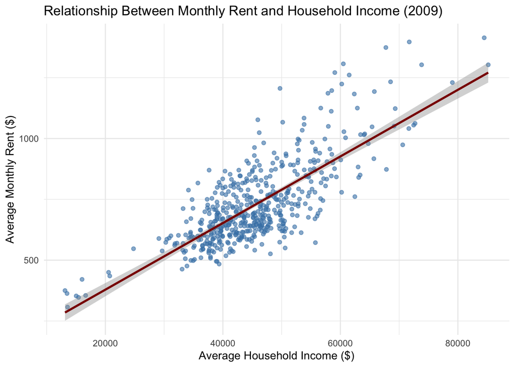

```r
library(dplyr)
library(ggplot2)

rent_income_2009 <- RENT |>
  filter(year == 2009) |>
  inner_join(
    INCOME |>
      filter(year == 2009) |>
      select(GEOID, household_income),
    by = "GEOID"
  )

ggplot(rent_income_2009, aes(x = household_income, y = monthly_rent)) +
  geom_point(alpha = 0.6, color = "steelblue") +
  geom_smooth(method = "lm", se = TRUE, color = "darkred") +
  labs(
    title = "Relationship Between Monthly Rent and Household Income (2009)",
    x = "Average Household Income ($)",
    y = "Average Monthly Rent ($)"
  ) +
  theme_minimal()
```

#Q2

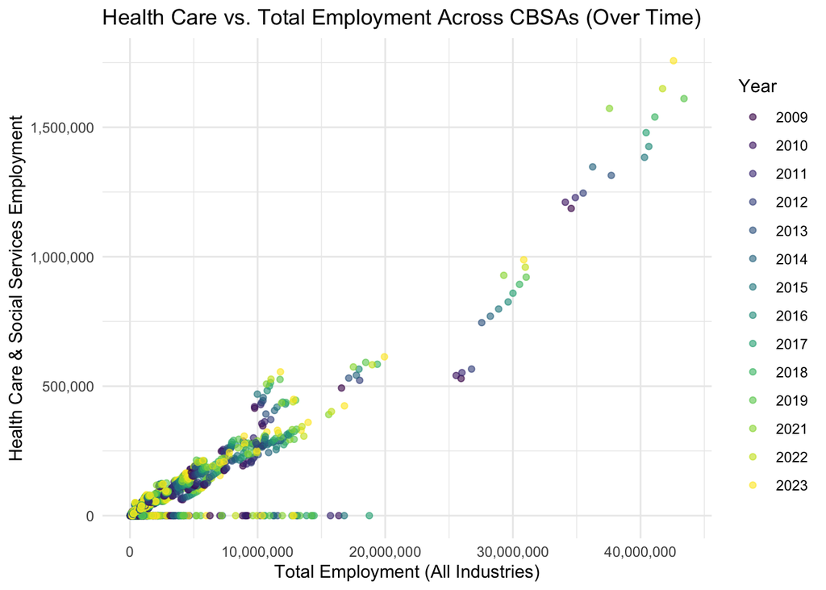

```r
 library(scales)

employment_totals <- WAGES |>
  group_by(FIPS, YEAR) |>
  summarize(total_employment = sum(EMPLOYMENT, na.rm = TRUE))


employment_health <- WAGES |>
  filter(INDUSTRY == 62) |>
  group_by(FIPS, YEAR) |>
  summarize(health_employment = sum(EMPLOYMENT, na.rm = TRUE))

employment_joined <- inner_join(employment_totals, employment_health, by = c("FIPS", "YEAR"))

ggplot(employment_joined, aes(x = total_employment, y = health_employment, color = as.factor(YEAR))) +
  geom_point(alpha = 0.6) +
  scale_color_viridis_d(name = "Year") +
  scale_x_continuous(labels = comma) +
  scale_y_continuous(labels = comma) +
  labs(
    title = "Health Care vs. Total Employment Across CBSAs (Over Time)",
    x = "Total Employment (All Industries)",
    y = "Health Care & Social Services Employment"
  ) +
  theme_minimal()
```

**Answer:** The plot shows that CBSAs with higher total employment generally have more health care workers, and the colored points highlight how health care employment changes over time across regions.

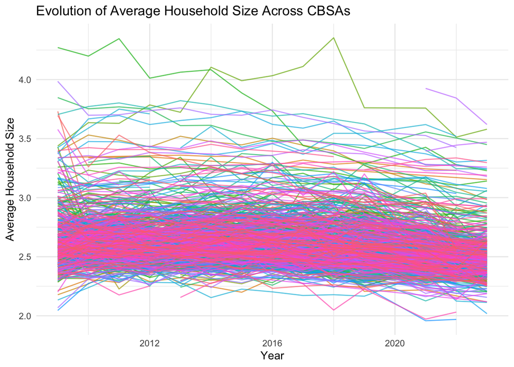

```r
household_size <- HOUSEHOLDS |>
  select(GEOID, NAME, households, year) |>
  left_join(
    POPULATION |> select(GEOID, population, year),
    by = c("GEOID", "year")
  ) |>
  mutate(avg_household_size = population / households)

ggplot(household_size, aes(x = year, y = avg_household_size, color = NAME)) +
  geom_line(alpha = 0.7) +
  labs(
    title = "Evolution of Average Household Size Across CBSAs",
    x = "Year",
    y = "Average Household Size",
    color = "Region"
  ) +
  theme_minimal() +
  theme(legend.position = "none")
```

**Answer:** The line chart shows how the average household size has changed over time across different CBSAs. It highlights trends in household composition, with some regions showing slight increases or decreases, reflecting demographic and social changes over the years.

## The relationship between total employment and total employment in the health care and social services sector (NAICS 62) across different CBSAs.

```r
t1 <- WAGES |>
  group_by(YEAR, FIPS) |>
  summarize(total_employment = sum(EMPLOYMENT))
```

```r
t2 <- WAGES |>
  filter(INDUSTRY == 62) |>
  group_by(YEAR, FIPS) |>
  summarize(health_and_social = sum(EMPLOYMENT))
```

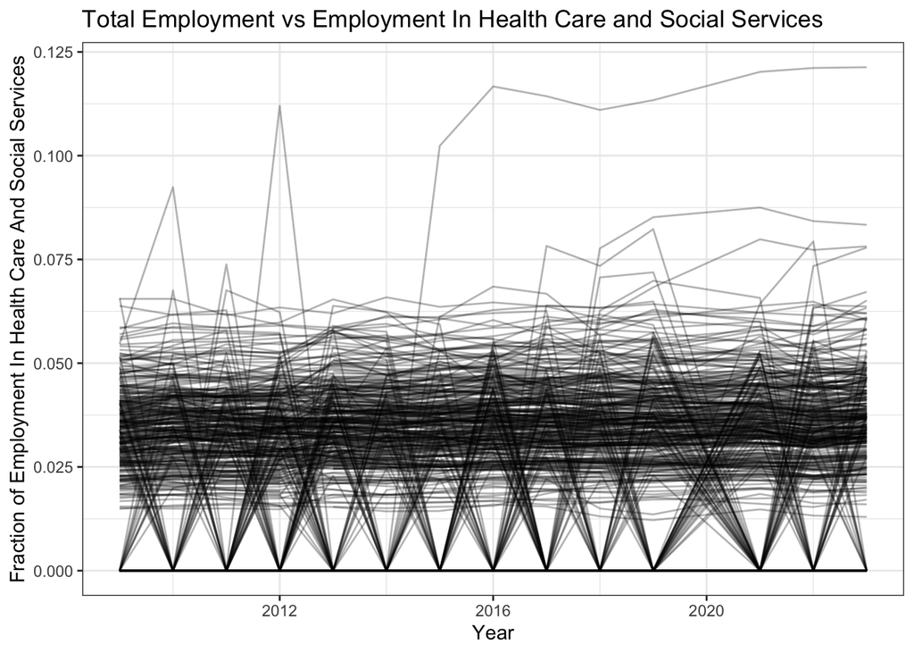

```r
t3 <- inner_join(t1, t2, join_by(YEAR == YEAR,
                                 FIPS ==FIPS)) |>
  mutate(fraction = health_and_social / total_employment)

ggplot(t3, aes(x = YEAR, y = fraction, group = FIPS)) +
  geom_line(alpha=0.3) +
  theme_bw() +
  xlab("Year") +
  ylab("Fraction of Employment In Health Care And Social Services") +
  labs(title="Total Employment vs Employment In Health Care and Social Services")
```

## The evolution of average household size over time. Use different lines to represent different CBSAs.

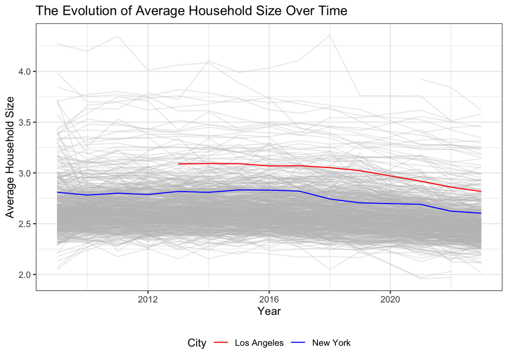

```r
library(dplyr)
library(ggplot2)
library(gghighlight)

Q3 <- POPULATION |>
  inner_join(HOUSEHOLDS, join_by(GEOID == GEOID, year == year)) |>
  mutate(
    average = population / households,
    city = case_when(
      GEOID == 35620 ~ "New York",
      GEOID == 31080 ~ "Los Angeles",
      TRUE ~ "Other"
    )
  )

ggplot(Q3, aes(x = year, y = average, group = GEOID, color = city)) +
  geom_line() +
  scale_color_manual(
    values = c("New York" = "blue", "Los Angeles" = "red", "Other" = "gray"),
    name = "City"
  ) +
  gghighlight(GEOID %in% c(35620, 31080),
              use_direct_label = FALSE,
              unhighlighted_params = list(alpha = 0.3)) +
  theme_bw() +
  theme(legend.position = "bottom") +
  xlab("Year") +
  ylab("Average Household Size") +
  labs(title = "The Evolution of Average Household Size Over Time")
```

## Task 4: Rent Burden

```r
# Join INCOME and RENT
income_rent <- INCOME %>%
  inner_join(RENT, by = c("GEOID", "NAME", "year"))

# Join POPULATION to the combined table
combined_data <- income_rent %>%
  inner_join(POPULATION, by = c("GEOID", "NAME", "year"))

# Calculate rent-to-income ratio (monthly rent / monthly household income)
combined_data <- combined_data %>%
  mutate(
    rent_to_income = monthly_rent / (household_income / 12)
  )

# Standardization
baseline <- combined_data %>%
  filter(year == min(year)) %>%
  summarize(avg = mean(rent_to_income, na.rm = TRUE)) %>%
  pull(avg)

combined_data <- combined_data %>%
  mutate(
    rent_burden_metric = case_when(
      rent_to_income >= baseline ~
        50 + 50 * (rent_to_income - baseline) / (max(rent_to_income, na.rm = TRUE) - baseline),
      rent_to_income < baseline ~
        50 - 50 * (baseline - rent_to_income) / (baseline - min(rent_to_income, na.rm = TRUE))
    )
  )

# Filter for Albany, GA Metro Area and prepare year
metro_data <- combined_data %>%
  filter(NAME == "Albany, GA Metro Area") %>%
  mutate(
    year = as.integer(year)
  )

# Group by year and compute average rent-to-income ratio
rent_trend <- metro_data %>%
  group_by(year) %>%
  summarise(
    avg_rent_to_income = mean(rent_to_income, na.rm = TRUE),
    median_rent_to_income = median(rent_to_income, na.rm = TRUE),
    .groups = "drop"
  )

# Ensure all years from 2009 to 2023 exist, even if NA
all_years <- data.frame(year = 2009:2023)
rent_trend <- all_years %>%
  left_join(rent_trend, by = "year")

rent_trend <- rent_trend %>%
  filter(!is.na(avg_rent_to_income), !is.na(year))

# Prepare table for Albany, GA Metro Area
albany_table <- rent_trend %>%
  mutate(
    avg_rent_to_income = percent(avg_rent_to_income, accuracy = 0.1)  # convert to %
  ) %>%
  select(year, avg_rent_to_income)

# Rename for display only
albany_table_display <- albany_table %>%
  rename(`Avg Rent to Income` = avg_rent_to_income)

# Display table
datatable(
  albany_table_display,
  options = list(pageLength = 15),
  rownames = FALSE,
  caption = htmltools::tags$caption(
    style = 'caption-side: top; text-align: center; font-weight: bold;',
    'Average Rent-to-Income Burden in Albany, GA Metro Area (2009–2023)'
  )
)
```

| year | Avg Rent to Income |
| --- | --- |
| 2009 | 20.7% |
| 2010 | 25.2% |
| 2011 | 24.9% |
| 2012 | 23.0% |
| 2013 | 22.7% |
| 2014 | 21.9% |
| 2015 | 21.3% |
| 2016 | 20.4% |
| 2017 | 19.1% |
| 2018 | 20.6% |

[output cut: 4 more lines]

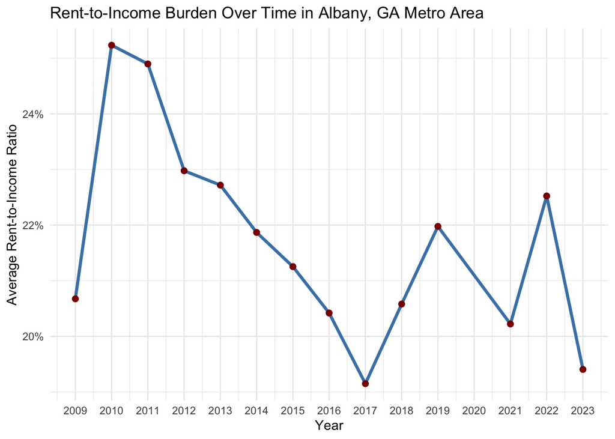

```r
# Plot
ggplot(rent_trend, aes(x = year, y = avg_rent_to_income)) +
  geom_line(color = "steelblue", linewidth = 1.2, group = 1) +
  geom_point(color = "darkred", size = 2) +
  scale_y_continuous(labels = percent_format(accuracy = 1)) +
  scale_x_continuous(breaks = 2009:2023) +
  labs(
    title = "Rent-to-Income Burden Over Time in Albany, GA Metro Area",
    x = "Year",
    y = "Average Rent-to-Income Ratio"
  ) +
  theme_minimal()
```

## Pick a single Metropolitan Area and see how rent burden has changed over time

```r
standard_ratio <- INCOME |>
  inner_join(RENT, join_by(GEOID == GEOID, year == year, NAME == NAME)) |>
  mutate(rent_to_income = (12 * monthly_rent) / household_income)

baseline <- standard_ratio |>
  filter(year == 2009) |>
  summarize(baseline = mean(rent_to_income))

standard_ratio <- standard_ratio |>
  mutate(standardized_metric = rent_to_income / baseline[[1]])

standard_ratio |>
  filter(GEOID == 35620) |>
  arrange(year) |>
  select(NAME, year, rent_to_income, standardized_metric) |>
  rename(Year = year,
         `Rent to Income Ratio` = rent_to_income,
         `Standardized Metric` = standardized_metric) |>
  datatable(options = list(searching = FALSE, info = FALSE))
```

|  | NAME | Year | Rent to Income Ratio | Standardized Metric |
| --- | --- | --- | --- | --- |
| 1 | New York-Northern New Jersey-Long Island, NY-NJ-PA Metro Area | 2009 | 0.2146707586623627 | 1.106345130601893 |
| 2 | New York-Northern New Jersey-Long Island, NY-NJ-PA Metro Area | 2010 | 0.2228430248518417 | 1.148462403401646 |
| 3 | New York-Northern New Jersey-Long Island, NY-NJ-PA Metro Area | 2011 | 0.2285549244247617 | 1.177899725551918 |
| 4 | New York-Northern New Jersey-Long Island, NY-NJ-PA Metro Area | 2012 | 0.226751273795755 | 1.168604281201963 |
| 5 | New York-Newark-Jersey City, NY-NJ-PA Metro Area | 2013 | 0.2256407138296902 | 1.162880806713154 |
| 6 | New York-Newark-Jersey City, NY-NJ-PA Metro Area | 2014 | 0.2292070497718665 | 1.181260573143863 |
| 7 | New York-Newark-Jersey City, NY-NJ-PA Metro Area | 2015 | 0.228328702558806 | 1.176733849671125 |
| 8 | New York-Newark-Jersey City, NY-NJ-PA Metro Area | 2016 | 0.2246547143830758 | 1.15779927770876 |
| 9 | New York-Newark-Jersey City, NY-NJ-PA Metro Area | 2017 | 0.2195626791211124 | 1.131556539983186 |
| 10 | New York-Newark-Jersey City, NY-NJ-PA Metro Area | 2018 | 0.2192716430082316 | 1.130056631992358 |

[output cut: 4 more lines]

## Highlight the Metro Areas highest and lowest with the highest and lowest rent burden

```r
standard_ratio |>
  filter(standardized_metric == max(standardized_metric) |
         standardized_metric == min(standardized_metric)) |>
  select(NAME, year, rent_to_income, standardized_metric) |>
  rename(Year = year,
         `Rent to Income Ratio` = rent_to_income,
         `Standardized Metric` = standardized_metric) |>
  datatable(options = list(searching = FALSE, info = FALSE))
```

|  | NAME | Year | Rent to Income Ratio | Standardized Metric |
| --- | --- | --- | --- | --- |
| 1 | Bismarck, ND Metro Area | 2009 | 0.1231254932912391 | 0.6345498138848349 |
| 2 | Mayagüez, PR Metro Area | 2018 | 0.3819406799349493 | 1.968401351249768 |

## Task 5: Housing Growth

```r
#Prepare and join

# Fixing join keys (PERMITS has CBSA; POPULATION has GEOID)
# Making sure both sides use the same type; tidycensus GEOID is typically numeric for CBSA
PERMITS_fixed <- PERMITS %>%
  rename(GEOID = CBSA) %>%
  mutate(GEOID = as.numeric(GEOID))  # if POPULATION$GEOID is character, change to as.character()

# Join population & permits
hg <- POPULATION %>%
  mutate(GEOID = as.numeric(GEOID)) %>%            # match type to PERMITS_fixed
  inner_join(PERMITS_fixed, by = c("GEOID", "year")) %>%
  mutate(NAME = enc2utf8(NAME)) %>%
  arrange(GEOID, year)

# 5-year population growth (starts in 2014)
hg <- hg %>%
  group_by(GEOID) %>%
  mutate(
    pop_5yrs_ago     = dplyr::lag(population, 5),
    pop_growth_count = population - pop_5yrs_ago,
    pop_growth_rate  = pop_growth_count / pop_5yrs_ago   # e.g., 0.07 = +7% over 5 yrs
  ) %>%
  ungroup()

# Two housing-growth metrics
# (a) Instantaneous: permits per 1,000 residents this year
# (b) Rate-based: permits per person of 5-year population growth (only when growth > 0)
hg <- hg %>%
  mutate(
    inst_growth = (new_housing_units_permitted / pmax(population, 1)) * 1000,
    rate_denom  = dplyr::if_else(is.na(pop_growth_count) | pop_growth_count <= 0, NA_real_, pop_growth_count * 1.0),
    rate_growth = new_housing_units_permitted / rate_denom
  )

# Standardizing each metric on 0–100
hg <- hg %>%
  mutate(
    inst_index = rescale(inst_growth, to = c(0, 100), na.rm = TRUE),
    rate_index = rescale(rate_growth, to = c(0, 100), na.rm = TRUE)
  )

# Composite index (equal-weight average of the two indices)
hg <- hg %>%
  mutate(
    composite_index = rowMeans(cbind(inst_index, rate_index), na.rm = TRUE)
  )

#formatting for tables
last_year <- max(hg$year, na.rm = TRUE)

pretty_tbl <- function(df) {
  df %>%
    transmute(
      `Metro Area` = NAME,
      Year         = year,
      Population   = population,
      Permits      = new_housing_units_permitted,
      `5-yr Pop Growth (%)` = pop_growth_rate * 100,
      `Instantaneous Growth (permits per 1k)`     = inst_growth,
      `Rate-based Growth (permits / 5-yr pop add)`= rate_growth,
      `Instantaneous Index (0–100)` = inst_index,
      `Rate-based Index (0–100)`     = rate_index,
      `Composite Index (0–100)`      = composite_index
    )
}

fmt_dt <- function(dtobj) {
  dtobj |>
    formatRound(c("Population","Permits"), digits = 0) |>
    formatPercentage("5-yr Pop Growth (%)", digits = 1) |>
    formatRound("Instantaneous Growth (permits per 1k)", digits = 2) |>
    formatRound("Rate-based Growth (permits / 5-yr pop add)", digits = 2) |>
    formatRound(c("Instantaneous Index (0–100)",
                  "Rate-based Index (0–100)",
                  "Composite Index (0–100)"), digits = 2)
}

# Rankings for the latest year
hg_latest <- hg %>% filter(year == last_year)
inst_rank <- hg_latest %>% arrange(desc(inst_index))

# Prepare top 10 and bottom 10 with highlight flags (use inst_index from inst_rank)
inst_top10_raw <- head(inst_rank, 10) %>%
  mutate(highlight_flag = if_else(inst_index == max(inst_index, na.rm = TRUE), "highest", ""))

inst_bottom10_raw <- tail(inst_rank, 10) %>%
  mutate(highlight_flag = if_else(inst_index == min(inst_index, na.rm = TRUE), "lowest", ""))

#pretty display tables, keep the highlight_flag column for styling
inst_top10 <- pretty_tbl(inst_top10_raw) %>%
  mutate(highlight_flag = inst_top10_raw$highlight_flag)

inst_bottom10 <- pretty_tbl(inst_bottom10_raw) %>%
  mutate(highlight_flag = inst_bottom10_raw$highlight_flag)

#compute 0-based target index for the highlight column to hide it
hide_target <- function(df, colname = "highlight_flag") {
  which(names(df) == colname) - 1
}

# Create DT for TOP 10 (highlighting the single 'highest' row)
dt_inst_high <- datatable(
  inst_top10,
  rownames = FALSE,
  options = list(
    pageLength = 10,
    autoWidth = TRUE,
    columnDefs = list(list(visible = FALSE, targets = hide_target(inst_top10, "highlight_flag")))
  ),
  caption = tags$caption(
    style = 'caption-side: top; text-align: left; font-weight: bold;',
    paste0("Instantaneous Housing Growth — Highest 10 (", last_year, ")")
  )
) %>%
  # Use the highlight_flag values to style entire rows
  formatStyle(
    columns = names(inst_top10),
    target = "row",
    valueColumns = "highlight_flag",
    backgroundColor = styleEqual(c("highest"), c("#1f77b4")),
    color = styleEqual(c("highest"), c("white")),
    fontWeight = styleEqual(c("highest"), c("bold"))
  ) %>%
  fmt_dt()

# Create DT for BOTTOM 10 (highlighting the single 'lowest' row)
dt_inst_low <- datatable(
  inst_bottom10,
  rownames = FALSE,
  options = list(
    pageLength = 10,
    autoWidth = TRUE,
    columnDefs = list(list(visible = FALSE, targets = hide_target(inst_bottom10, "highlight_flag")))
  ),
  caption = tags$caption(
    style = 'caption-side: top; text-align: left; font-weight: bold;',
    paste0("Instantaneous Housing Growth — Lowest 10 (", last_year, ")")
  )
) %>%
  formatStyle(
    columns = names(inst_bottom10),
    target = "row",
    valueColumns = "highlight_flag",
    backgroundColor = styleEqual(c("lowest"), c("#1f77b4")),
    color = styleEqual(c("lowest"), c("white")),
    fontWeight = styleEqual(c("lowest"), c("bold"))
  ) %>%
  fmt_dt()

# Print them
dt_inst_high
```

| Metro Area | Year | Population | Permits | 5-yr Pop Growth (%) | Instantaneous Growth (permits per 1k) | Rate-based Growth (permits / 5-yr pop add) | Instantaneous Index (0–100) | Rate-based Index (0–100) | Composite Index (0–100) | highlight_flag |
| --- | --- | --- | --- | --- | --- | --- | --- | --- | --- | --- |
| Salisbury, MD Metro Area | 2023 | 129710 | 4894 | -68.04015246899739 | 37.73032148639273 |  | 100 |  | 100 | highest |
| Myrtle Beach-Conway-North Myrtle Beach, SC Metro Area | 2023 | 397478 | 13176 | -14.36708928936908 | 33.14900447320355 |  | 87.84882706112172 |  | 87.84882706112172 |  |
| Punta Gorda, FL Metro Area | 2023 | 206134 | 4429 | 13.23990704982064 | 21.48602365451599 | 0.1837683083689473 | 56.91473179927948 | 0.3433588220587414 | 28.62904531066911 |  |
| Crestview-Fort Walton Beach-Destin, FL Metro Area | 2023 | 304818 | 5596 | 12.33554207543137 | 18.35849588935037 | 0.1671845124282983 | 48.61949035751425 | 0.3117844054329157 | 24.46563738147358 |  |
| North Port-Bradenton-Sarasota, FL Metro Area | 2023 | 910108 | 15928 | 13.10044861996545 | 17.50121963547183 | 0.1510937411068319 | 46.34570926197284 | 0.2811486740627802 | 23.31342896801781 |  |
| Daphne-Fairhope-Foley, AL Metro Area | 2023 | 253507 | 4363 | 19.22559587636623 | 17.21057012232404 | 0.1067296166735977 | 45.57481030678331 | 0.1966824063211812 | 22.88574635655224 |  |
| Sherman-Denison, TX Metro Area | 2023 | 146907 | 2447 | 12.02302882415739 | 16.65679647668253 | 0.1551975645335194 | 44.10601883965476 | 0.2889620740284327 | 22.1974904568416 |  |
| Cape Coral-Fort Myers, FL Metro Area | 2023 | 834573 | 13556 | 12.89852602188241 | 16.24303685836949 | 0.1421724401933948 | 43.00859103390112 | 0.2641631254650207 | 21.63637707968307 |  |
| Austin-Round Rock-San Marcos, TX Metro Area | 2023 | 2473275 | 38773 | 16.89400882019182 | 15.67678482983089 | 0.1084717217609275 | 41.50670275462368 | 0.1999992556137183 | 20.8533510051187 |  |
| Lakeland-Winter Haven, FL Metro Area | 2023 | 818330 | 12513 | 19.2061565981969 | 15.29089731526401 | 0.0949054585997406 | 40.48320101681403 | 0.1741700156351335 | 20.32868551622458 |  |

```r
dt_inst_low
```

| Metro Area | Year | Population | Permits | 5-yr Pop Growth (%) | Instantaneous Growth (permits per 1k) | Rate-based Growth (permits / 5-yr pop add) | Instantaneous Index (0–100) | Rate-based Index (0–100) | Composite Index (0–100) | highlight_flag |
| --- | --- | --- | --- | --- | --- | --- | --- | --- | --- | --- |
| Fairbanks-College, AK Metro Area | 2023 | 94840 | 49 | -4.877486133817438 | 0.5166596372838465 |  | 1.297020154761727 |  | 1.297020154761727 |  |
| Williamsport, PA Metro Area | 2023 | 112724 | 57 | -0.9811930675240027 | 0.5056598417373407 |  | 1.267845046906693 |  | 1.267845046906693 |  |
| Bay City, MI Metro Area | 2023 | 102500 | 38 | -1.668281545294947 | 0.3707317073170732 |  | 0.9099708611778257 |  | 0.9099708611778257 |  |
| Johnstown, PA Metro Area | 2023 | 130668 | 47 | -1.793256873149248 | 0.3596902072427832 |  | 0.8806851390762813 |  | 0.8806851390762813 |  |
| Decatur, IL Metro Area | 2023 | 100591 | 34 | -4.924339089422595 | 0.3380024057818294 |  | 0.8231618929316852 |  | 0.8231618929316852 |  |
| Enid, OK Metro Area | 2023 | 62023 | 10 | 0.7177538526493561 | 0.1612305112619512 | 0.02262443438914027 | 0.3543041703902544 | 0.0365518743643019 | 0.1954280223772782 |  |
| Weirton-Steubenville, WV-OH Metro Area | 2023 | 114106 | 16 | -4.644671747559834 | 0.1402204967311097 |  | 0.2985786400945715 |  | 0.2985786400945715 |  |
| Morgantown, WV Metro Area | 2023 | 141817 | 17 | 2.24066210555912 | 0.1198727938117433 | 0.00546975546975547 | 0.2446097799675962 | 0.003890535475340317 | 0.1242501577214682 |  |
| Danville, IL Micro Area | 2023 | 71652 | 8 | -8.031164563785955 | 0.1116507564338748 |  | 0.2228022085201768 |  | 0.2228022085201768 |  |
| Wheeling, WV-OH Metro Area | 2023 | 135517 | 11 | -4.061477905050476 | 0.08117062803928658 |  | 0.141958793786903 |  | 0.141958793786903 | lowest |

## Task 6: Visualization

**The Relationships between Rent Burden and Housing Growth**

```r
library(dplyr)
library(ggplot2)
library(scales)

# Example: create rent burden index
rent_burden_data <- INCOME %>%
  inner_join(RENT, by = c("GEOID", "year")) %>%
  mutate(
    rent_to_income = monthly_rent * 12 / household_income,
    rent_burden_index = scales::rescale(rent_to_income, to = c(0, 100))
  ) %>%
  inner_join(POPULATION %>% select(GEOID, year, NAME, population),
             by = c("GEOID", "year"))

# Example: compute housing growth metrics
housing_growth_data <- POPULATION %>%
  inner_join(PERMITS, by = c("GEOID" = "CBSA", "year")) %>%
  group_by(GEOID) %>%
  arrange(year) %>%
  mutate(
    permits_per_1k = new_housing_units_permitted / population * 1000
  ) %>%
  ungroup()
```

```r
yimby_analysis <- rent_burden_data %>%
  group_by(GEOID, NAME) %>%
  summarise(
    rent_burden_2009 = rent_burden_index[year == 2009],
    rent_burden_latest = rent_burden_index[year == max(year)],
    rent_burden_change = rent_burden_latest - rent_burden_2009,
    .groups = "drop"
  ) %>%
  inner_join(
    housing_growth_data %>%
      group_by(GEOID, NAME) %>%
      summarise(
        total_pop_growth = last(population) - first(population),
        pop_growth_rate = (last(population) - first(population)) / first(population) * 100,
        avg_permits_per_1k = mean(permits_per_1k, na.rm = TRUE),
        .groups = "drop"
      ),
    by = c("GEOID", "NAME")
  ) %>%
  mutate(
    high_early_burden = rent_burden_2009 > median(rent_burden_2009, na.rm = TRUE),
    burden_decreased = rent_burden_change < 0,
    pop_grew = total_pop_growth > 0,
    above_avg_housing = avg_permits_per_1k > median(avg_permits_per_1k, na.rm = TRUE),
    yimby_score = as.integer(high_early_burden) +
                  as.integer(burden_decreased) +
                  as.integer(pop_grew) +
                  as.integer(above_avg_housing),
    is_yimby = yimby_score == 4
  )
```

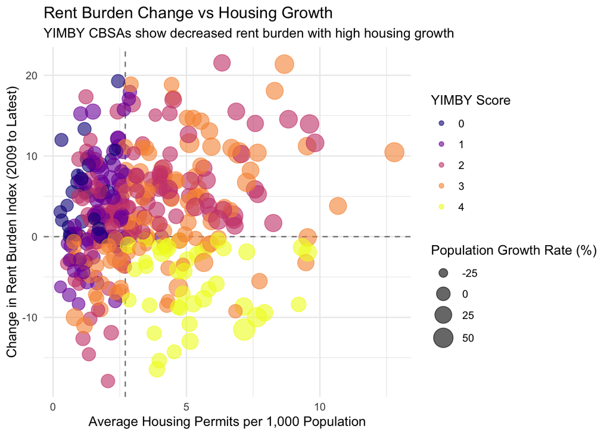

```r
ggplot(yimby_analysis, aes(x = avg_permits_per_1k, y = rent_burden_change,
                            color = factor(yimby_score), size = pop_growth_rate)) +
  geom_hline(yintercept = 0, linetype = "dashed", color = "gray50") +
  geom_vline(xintercept = median(yimby_analysis$avg_permits_per_1k, na.rm = TRUE),
             linetype = "dashed", color = "gray50") +
  geom_point(alpha = 0.6) +
  scale_color_viridis_d(option = "plasma") +
  scale_size_continuous(range = c(1, 8)) +
  labs(
    title = "Rent Burden Change vs Housing Growth",
    subtitle = "YIMBY CBSAs show decreased rent burden with high housing growth",
    x = "Average Housing Permits per 1,000 Population",
    y = "Change in Rent Burden Index (2009 to Latest)",
    color = "YIMBY Score",
    size = "Population Growth Rate (%)"
  ) +
  theme_minimal()
```

**Answer:** This scatterplot shows how housing growth relates to changes in rent burden. Points are colored by YIMBY score and sized by population growth. CBSAs meeting all YIMBY criteria cluster in the ideal area, showing that cities with more construction reduced rent pressures while growing in population.

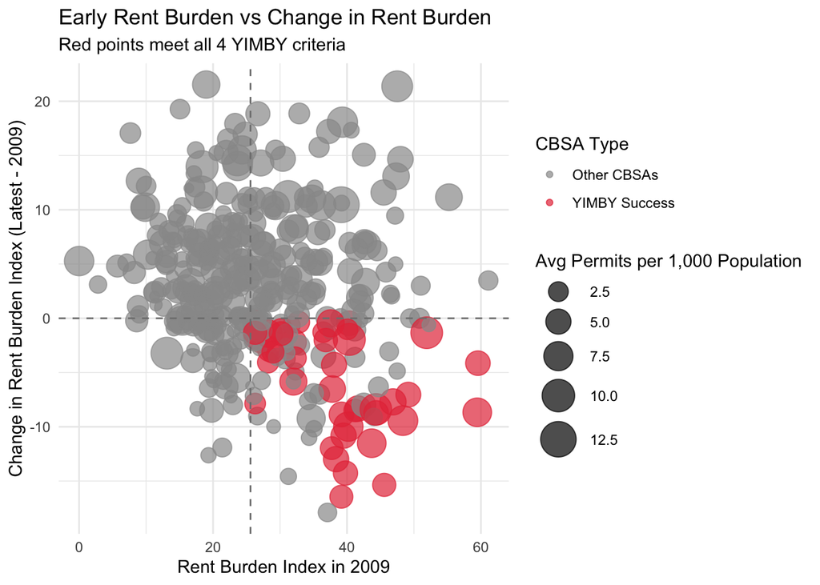

```r
# Second visualization: Early Rent Burden vs Change, sized by Housing Growth
ggplot(yimby_analysis, aes(x = rent_burden_2009, y = rent_burden_change,
                            color = factor(is_yimby), size = avg_permits_per_1k)) +
  geom_point(alpha = 0.7) +
  geom_hline(yintercept = 0, linetype = "dashed", color = "gray50") +
  geom_vline(xintercept = median(yimby_analysis$rent_burden_2009, na.rm = TRUE),
             linetype = "dashed", color = "gray50") +
  scale_color_manual(values = c("TRUE" = "#E63946", "FALSE" = "gray60"),
                     labels = c("TRUE" = "YIMBY Success", "FALSE" = "Other CBSAs")) +
  scale_size_continuous(range = c(2, 10)) +
  labs(
    title = "Early Rent Burden vs Change in Rent Burden",
    subtitle = "Red points meet all 4 YIMBY criteria",
    x = "Rent Burden Index in 2009",
    y = "Change in Rent Burden Index (Latest - 2009)",
    color = "CBSA Type",
    size = "Avg Permits per 1,000 Population"
  ) +
  theme_minimal()
```

**Answer:** This plot compares early rent burden with later changes. Red points highlight CBSAs meeting all YIMBY criteria. It shows cities that started expensive but successfully lowered rent burden through more housing construction, while still attracting population growth.

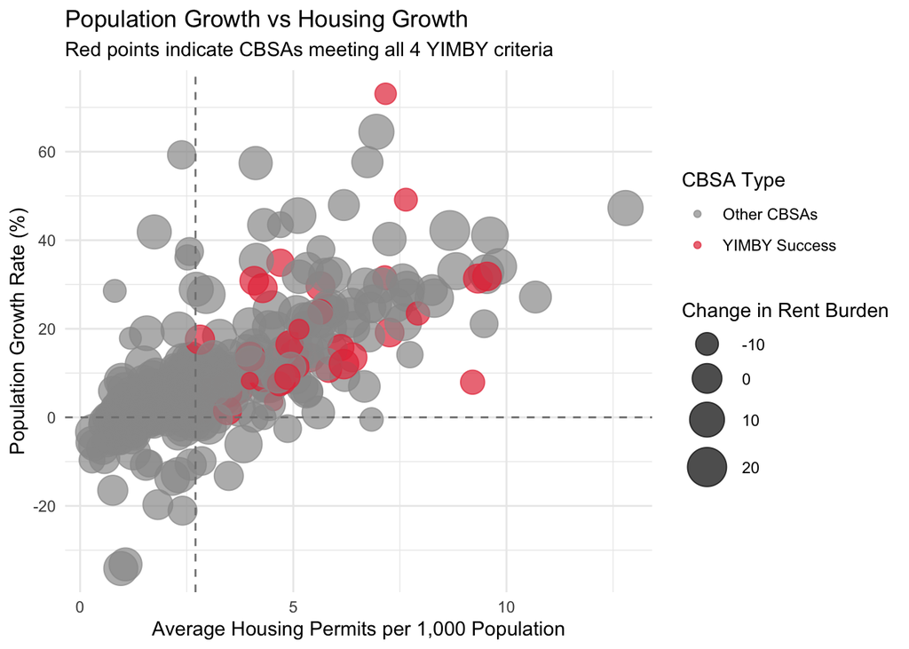

```r
# Third visualization: Population Growth vs Housing Growth
ggplot(yimby_analysis, aes(x = avg_permits_per_1k, y = pop_growth_rate,
                            color = factor(is_yimby), size = rent_burden_change)) +
  geom_point(alpha = 0.7) +
  geom_hline(yintercept = 0, linetype = "dashed", color = "gray50") +
  geom_vline(xintercept = median(yimby_analysis$avg_permits_per_1k, na.rm = TRUE),
             linetype = "dashed", color = "gray50") +
  scale_color_manual(values = c("TRUE" = "#E63946", "FALSE" = "gray60"),
                     labels = c("TRUE" = "YIMBY Success", "FALSE" = "Other CBSAs")) +
  scale_size_continuous(range = c(2, 10)) +
  labs(
    title = "Population Growth vs Housing Growth",
    subtitle = "Red points indicate CBSAs meeting all 4 YIMBY criteria",
    x = "Average Housing Permits per 1,000 Population",
    y = "Population Growth Rate (%)",
    color = "CBSA Type",
    size = "Change in Rent Burden"
  ) +
  theme_minimal()
```

## Policy Brief

**Objective:** Encourage cities to adopt housing-friendly policies that increase supply, lower rent burden, and support population growth.

**Proposed Sponsors:**

**Primary Sponsor:** Wilmington, NC – a YIMBY success story showing decreased rent burden, population growth, and strong housing development.

**Co-Sponsor:** Danville, IL – a NIMBY/low-growth city highlighting where policy incentives are needed.

**Rationale:** Wilmington demonstrates that affordability and growth can coexist. Danville highlights the risks of restricted housing supply, where rents remain high despite population stagnation.

**Targeted Support from Occupations:**

Wilmington, NC: Teachers, Firefighters – benefit from lower housing costs, stronger labor support for policy.

Danville, IL: Nurses, Police Officers – benefit from potential rent reduction, financial stability, and union support for legislation.

**Metrics to Identify YIMBY Cities:**

Rent Burden Index: Shows affordability trends relative to income.

Housing Growth Metric: Measures permits per population to capture active development.

**Composite Score:** Combines rent burden improvement and housing growth to flag successful YIMBY metros.

**Conclusion:** Cities scoring high on YIMBY criteria are ideal for federal program pilots. Supporting local housing expansion benefits residents, strengthens local economies, and gains political and labor support.